# EDA

# Pases Totales

A continuacion se hara un analisis de la cantidad de pases completados para todos los jugadores de las 5 grandes ligas de Europa (Inglaterra, Francia, España, Alemania, Italia). Los datos analizados son de los años 2018 a 2021. Para realizar el analisis se utilizara aquellos jugadores que hayan jugado mas del 10% de los minutos posibles.

## Estadistica Descriptiva:

Media:

Por el teorema central del limite (TCL) la media muestral se aproxima a la esperanza de la variable aleatorea X = Pases completados por jugador en una temporada

```
## [1] 772.08
```

Mediana

```
## [1] 682
```

Desvio Estandar

```
## [1] 446.63
```

### Distribucion de Pases

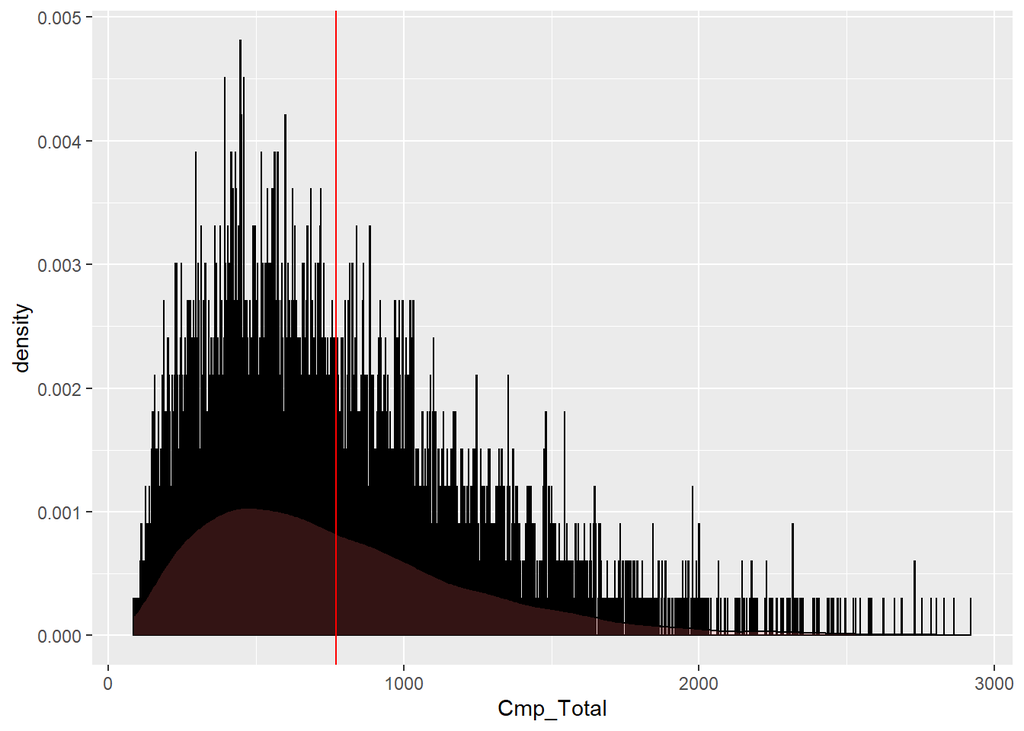

Esta funcion de densidad parece ser parecida a la distribucion de una funcion gamma. Al compararlo con una funcion de distribucion gamma de parametro “shape” igual a dos y luego tres se podria sospechar que el parametro de la distribucion de los datos va a estar cercano a esos numeros.

Distribucion Gamma, Shape = 2:

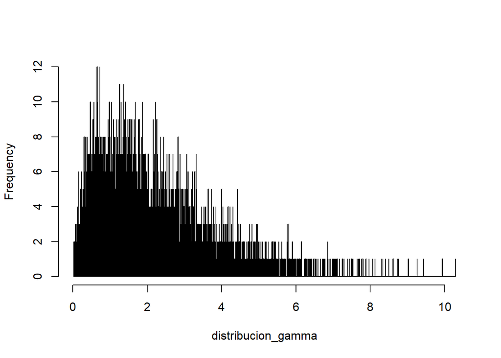

Distribucion Gamma, Shape = 3:

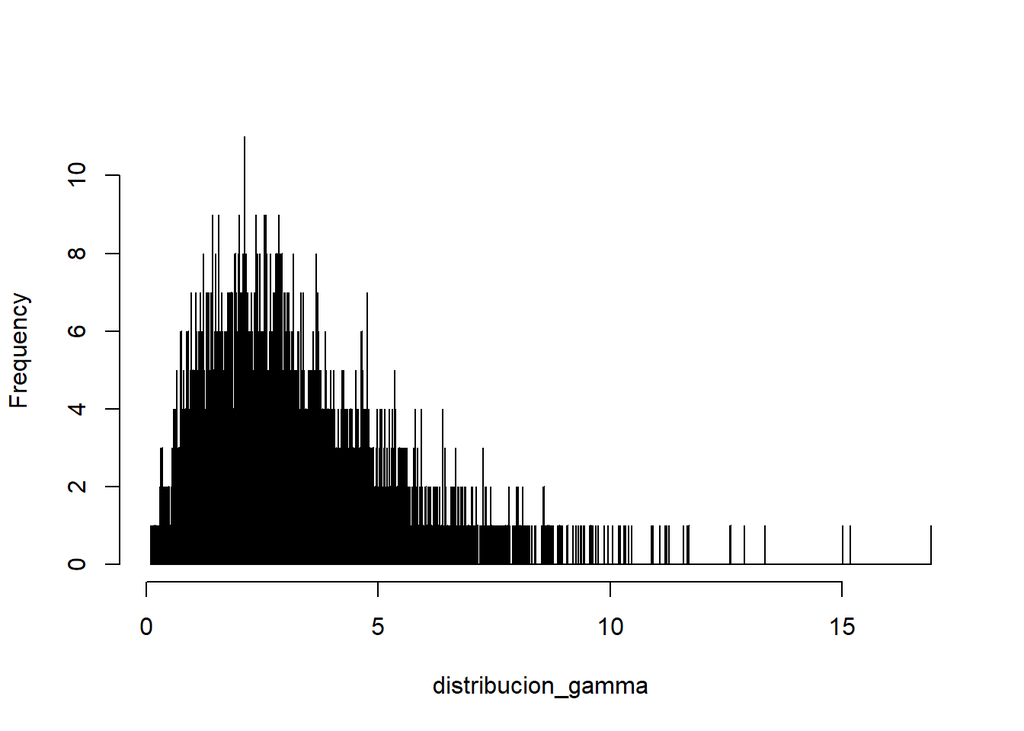

Voy a utilizar el metodo estimacion de maxima verisimilitud (EMV) para calcular los parametros de la funcion gamma de los datos. El calculo devuelve los siguientes parametros:

```
## Fitting of the distribution ' gamma ' by maximum likelihood
## Parameters:
##          estimate   Std. Error
## shape 3.054027981 4.074206e-02
## rate  0.003955296 5.336346e-05
```

La distribucion de una funcion gamma de los parametros calculados se grafica de la siguiente forma:

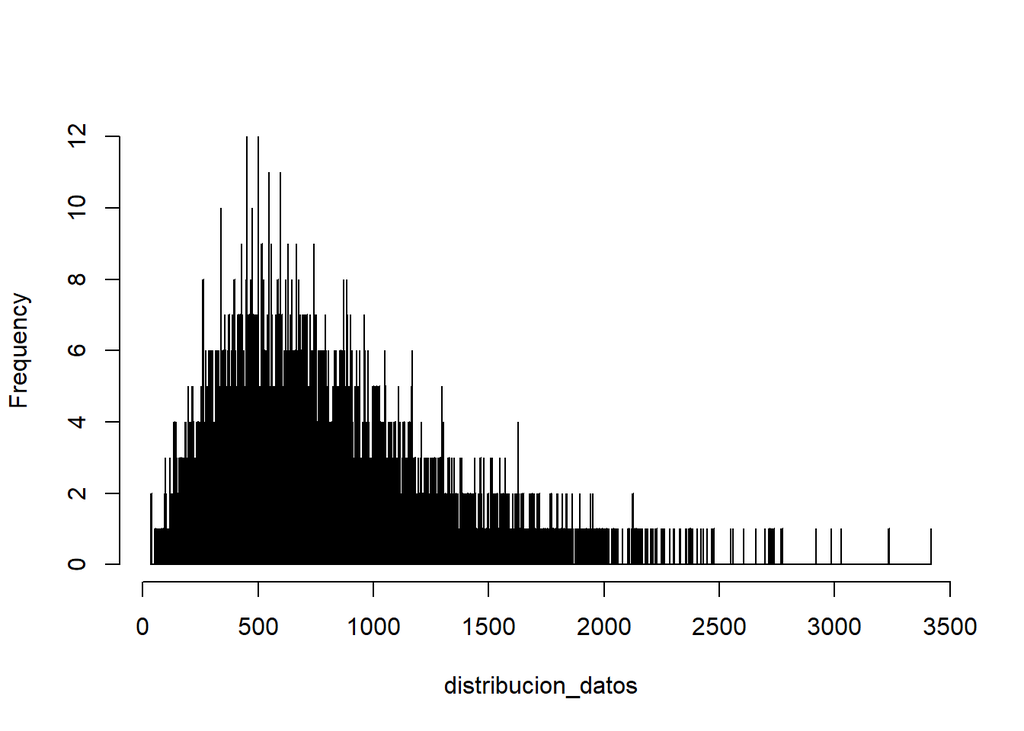

A la vista, parece estar bastante acertado a la distribucion de los datos de pases.

Para comprobar si los datos efectivamente siguen una distibucion gamma de los parametros encontrados voy a comparar las dos distribuciones

[figure not shown]

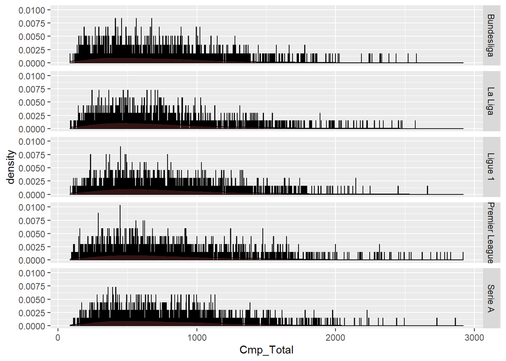

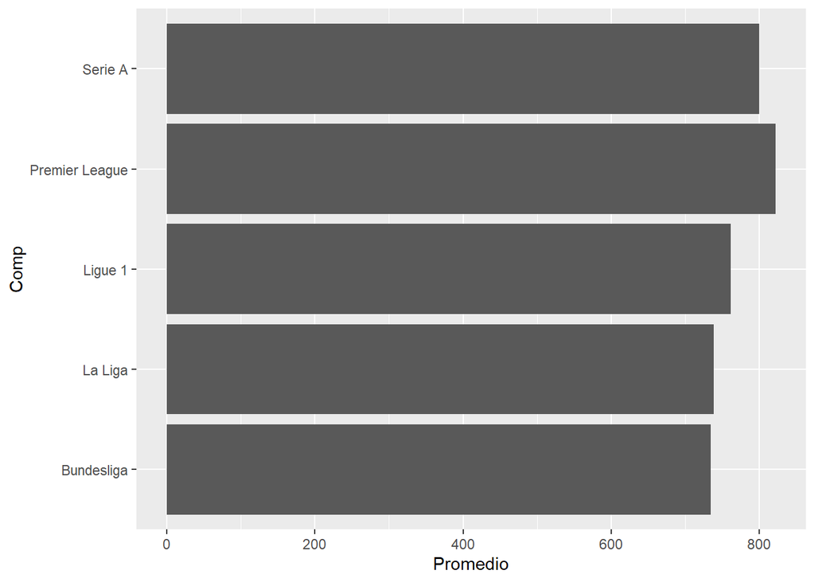

```
## [1] 38.4301
```

# Jugadores elite

Mirando los graficos de distribucion de cantidad de pases, se puede observar como la Premier League parece tener mas jugadores que superan a los 1500 pases

Para ver si esto es verdadero, voy a calcular la proporcion de jugadores con mas de 1500 pases para todas las ligas menos la Premier League.

Proporcion de jugadores con mas de 1500 pases:

```
## [1] "7%"
```

Ahora voy a hacer el mismo calculo para la Premier League.

Proporcion de jugadores con mas de 1500 pases en la Premier League:

```
## [1] "11%"
```

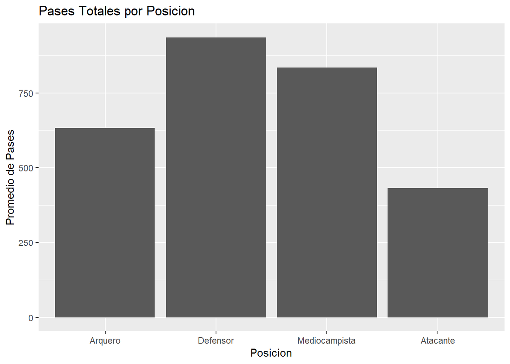